# Course Project 1 - Reproducible Research

Ariane Biais

19/08/2020

## Loading and preprocessing the data

The first work to perform is to unzip the file and to read the csv while assigning it to a variable name.

```r
unzip("activity.zip")
data_activity<-read.csv("activity.csv")
head(data_activity)
```

```
##   steps       date interval
## 1    NA 2012-10-01        0
## 2    NA 2012-10-01        5
## 3    NA 2012-10-01       10
## 4    NA 2012-10-01       15
## 5    NA 2012-10-01       20
## 6    NA 2012-10-01       25
```

The dataset has 17568 rows and 3 columns.

```r
sum_steps<-tapply(complete_activity$steps,complete_activity$date,sum)
```

The histogram of the total number of steps taken each day is created using this code :

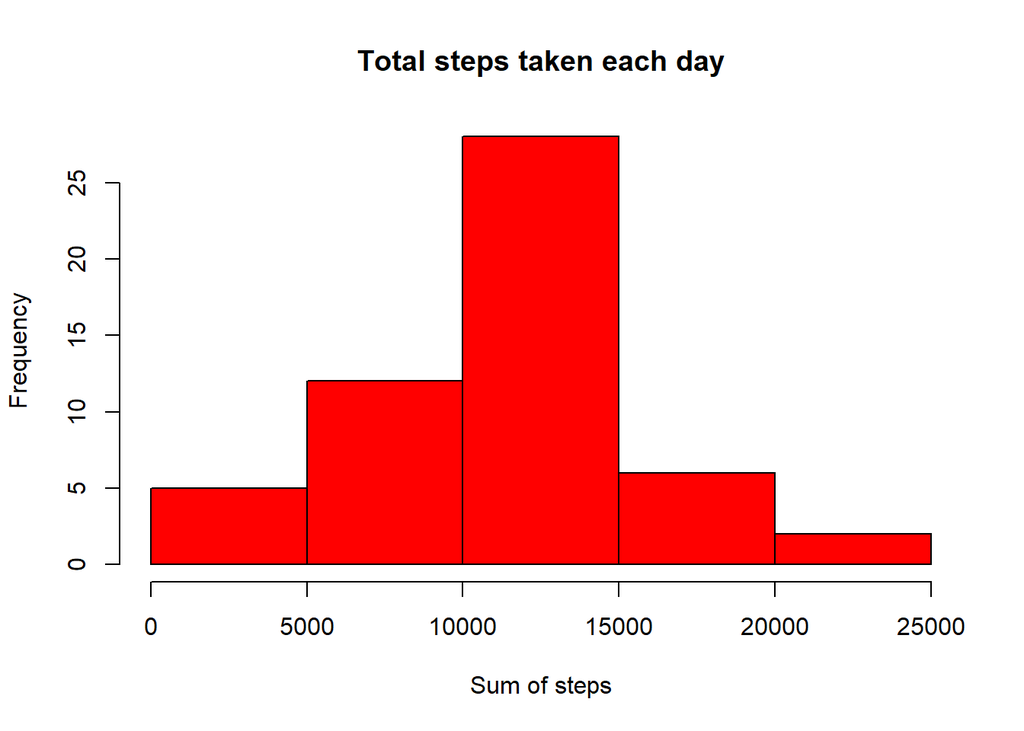

```r
hist(sum_steps,main="Total steps taken each day",xlab="Sum of steps",col="red")
```

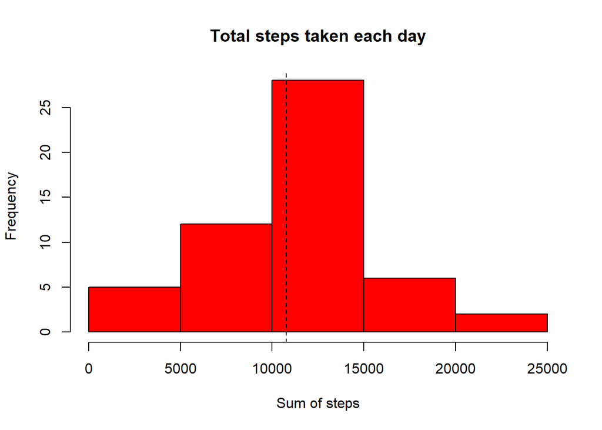

```r
mean_steps<-mean(sum_steps)
median_steps<-median(sum_steps)
hist(sum_steps,main="Total steps taken each day",xlab="Sum of steps",col="red")
abline(v=median_steps,lty=2,col="black")
```

## Average daily activity pattern

With the dataset, I create another dataframe with only 2 colums : the mean of steps per interval, and the interval column

```r
mean_interval<-tapply(complete_activity$steps,complete_activity$interval,mean)
mean_interval<-as.data.frame(mean_interval)
mean_interval$interval<-as.numeric(rownames(mean_interval))
rownames(mean_interval)<-seq(1,nrow(mean_interval),by=1)
head(mean_interval)
```

```
##   mean_interval interval
## 1     1.7169811        0
## 2     0.3396226        5
## 3     0.1320755       10
## 4     0.1509434       15
## 5     0.0754717       20
## 6     2.0943396       25
```

Now I create a time series plot based on this newly created datasetand add a line for the maximum value.

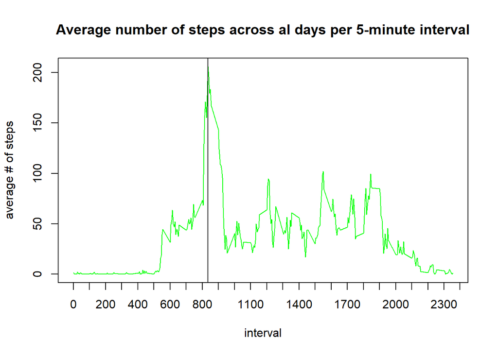

```r
with(mean_interval,plot(interval,mean_interval,type="l",xaxp=c(0,2500,2500/100),col="green",ylab="average # of steps",main="Average number of steps across al days per 5-minute interval"))
abline(v=mean_interval[mean_interval[,1]==max(mean_interval[,1]),2])
```

```r
max_interval<-mean_interval[mean_interval[,1]==max(mean_interval[,1]),2]
```

The maximum number of steps occurs at the interval 835.

## Imputing missing values

```r
na<-sum(is.na(data_activity$steps))
```

There are 2304 NA in the dataset for the steps column.

```r
## Creating a data frame with one row of mean of steps PER interval
av_steps<-tapply(complete_activity$steps,complete_activity$interval,mean)
av_steps<-data.frame(av_steps,interval=names(av_steps))
rownames(av_steps)<-seq(1,nrow(av_steps),by=1)

## Isolating the matrice of na values and replacing each NA step value by the corresponding value in the av_steps dataframe
na_activity<-data_activity[!good,]
for(i in av_steps$interval){
        na_activity[na_activity$interval==i,1]<-av_steps[av_steps$interval==i,1]
}

## Merge the complete set and the na newly completed set
data_new<-rbind(complete_activity,na_activity)
head(data_new)
```

```
##     steps       date interval
## 289     0 2012-10-02        0
## 290     0 2012-10-02        5
## 291     0 2012-10-02       10
## 292     0 2012-10-02       15
## 293     0 2012-10-02       20
## 294     0 2012-10-02       25
```

Now I have created a complete data set, I can rerun the code written for the first part, but by replacing the old data set with the new one.

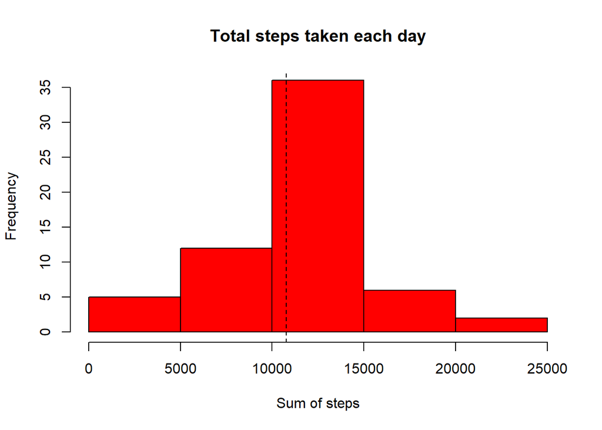

```r
sum_steps_all<-tapply(data_new$steps,data_new$date,sum)
mean_steps_all<-mean(sum_steps_all)
median_steps_all<-median(sum_steps_all)
hist(sum_steps_all,main="Total steps taken each day",xlab="Sum of steps",col="red")
abline(v=mean_steps_all,lty=2,col="black")
```

## Activity patterns across weekdays and weekends

I first have to convert the date of the global dataset and list their week day value.

```r
data_new$date<-as.Date(data_new$date,"%Y-%m-%d")
data_wd<-weekdays(data_new$date)
```

I then add two columns : the day, and the related type.

```r
data_new$day<-data_wd
 for(i in 1:nrow(data_new)){
         if(data_new$day[i]=="mardi"|data_new$day[i]=="lundi"|data_new$day[i]=="mercredi"|data_new$day[i]=="jeudi"|data_new$day[i]=="vendredi"){ data_new$type_of_day[i]<-"weekday"}
         if(data_new$day[i]=="samedi"|data_new$day[i]=="dimanche"){ data_new$type_of_day[i]<-"weekend"}
                 head(data_new)
}
```

After having created an horrible plot with two many points, I realized I had to once again compute the mean for each interval, but this time separating weekdays and weekends. So I reused the code for part 2, but doubling it per type of day.

I just have to plot the data using the lattice package.

```r
## Splitting the last database per type of day
spl2<-split(data_new,data_new$type_of_day)
data_new_weekend<-spl2[["weekend"]]
data_new_weekday<-spl2[["weekday"]]

## Reuse code from part 2, but x2
mean_interval_weekday<-tapply(data_new_weekday$steps,data_new_weekday$interval,mean)
mean_interval_weekend<-tapply(data_new_weekend$steps,data_new_weekend$interval,mean)

mean_interval_weekend<-as.data.frame(mean_interval_weekend)
mean_interval_weekend$interval<-as.numeric(rownames(mean_interval_weekend))
rownames(mean_interval_weekend)<-seq(1,nrow(mean_interval_weekend),by=1)
colnames(mean_interval_weekend)[1]<-"Average_steps"
mean_interval_weekend$type_of_day<-rep("weekend",nrow(mean_interval_weekend))

mean_interval_weekday<-as.data.frame(mean_interval_weekday)
mean_interval_weekday$interval<-as.numeric(rownames(mean_interval_weekday))
rownames(mean_interval_weekday)<-seq(1,nrow(mean_interval_weekday),by=1)
colnames(mean_interval_weekday)[1]<-"Average_steps"
mean_interval_weekday$type_of_day<-rep("weekday",nrow(mean_interval_weekday))

## Binding the two
final_data<-rbind(mean_interval_weekday,mean_interval_weekend)
```

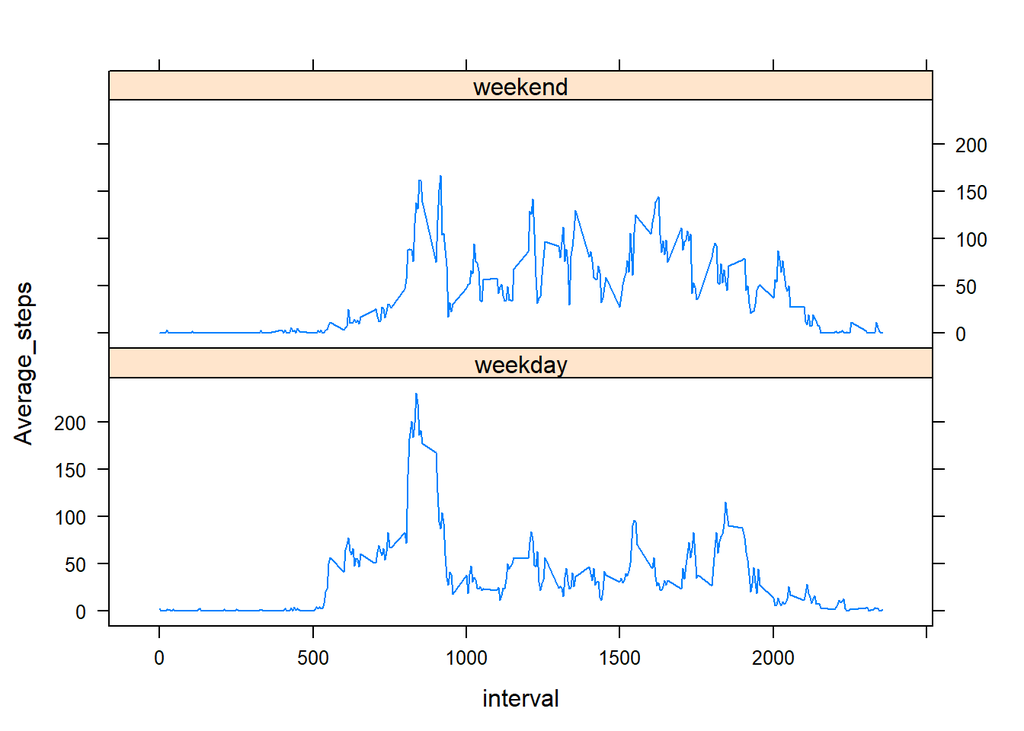

```r
library(lattice)
xyplot(Average_steps~interval|type_of_day,data=final_data,layout=c(1,2),type="l")
```